# R_ML_assignment

Yair_Meidan

Friday, September 26, 2015

# Using machine learning to predict activity quality from activity monitors

# Executive summary

In this assignment, the prediction of barbell lifting quality is treated as a classification problem, based on sensor data. Several approaches of decision tree induction are proposed and evaluated. An accuracy of about 99% is estimated on a validation set as well as on the training set using 10-fold cross-validation, by three models: plain C5.0, Random Forest and Boosted Tree. A slightly lower accuracy of about 96% is estimated by a fourth model, namely a C5.0 with principal components instead of the original predictors. For prediction on the testing set, a combined predictor is being used, based on majority vote from the top three predictors.

# Background

Using devices such as Jawbone Up, Nike FuelBand, and Fitbit it is now possible to collect a large amount of data about personal activity relatively inexpensively. These type of devices are part of the quantified self movement – a group of enthusiasts who take measurements about themselves regularly to improve their health, to find patterns in their behavior, or because they are tech geeks. One thing that people regularly do is quantify how much of a particular activity they do, but they rarely quantify how well they do it. In this project, the goal is to use data from accelerometers on the belt, forearm, arm, and dumbell of 6 participants. They were asked to perform barbell lifts correctly and incorrectly in 5 different ways. More information is available from the website [here](http://groupware.les.inf.puc-rio.br/har) (see the section on the Weight Lifting Exercise Dataset).  
The dataset and literature review for this project are based on the following publication: Ugulino, W.; Cardador, D.; Vega, K.; Velloso, E.; Milidiu, R.; Fuks, H. Wearable Computing: Accelerometers’ Data Classification of Body Postures and Movements. Proceedings of 21st Brazilian Symposium on Artificial Intelligence. Advances in Artificial Intelligence - SBIA 2012. In: Lecture Notes in Computer Science. , pp. 52-61. Curitiba, PR: Springer Berlin / Heidelberg, 2012. ISBN 978-3-642-34458-9. DOI: 10.1007/978-3-642-34459-6_6.

# Goal

The goal of this project is to predict the manner in which they did the exercise.

# Data

The training data for this project are available [here](https://d396qusza40orc.cloudfront.net/predmachlearn/pml-training.csv).  
The test data are available [here](https://d396qusza40orc.cloudfront.net/predmachlearn/pml-testing.csv).  
The data for this project come from [this source](http://groupware.les.inf.puc-rio.br/har).

## Get data

Download the training and testing files only if needed, then read the training file.

```r
# download training file
if (!file.exists("pml-training.csv")) {
  fileUrl<-"http://d396qusza40orc.cloudfront.net/predmachlearn/pml-training.csv"
  download.file(fileUrl,destfile="pml-training.csv")
}

# download testing file
if (!file.exists("pml-testing.csv")) {
  fileUrl<-"http://d396qusza40orc.cloudfront.net/predmachlearn/pml-testing.csv"
  download.file(fileUrl,destfile="pml-testing.csv")
}

# read training file
tr_orig<-read.csv(
  "pml-training.csv"
  ,header = TRUE
  ,sep=","
  ,na.strings=c("NA","#DIV/0!")
)
```

## Load required packages for analysis

```r
library(caret) # for pre-processing, visualization, modeling and prediction
library(ggplot2) # for visualization
library(xtable) # for table output generation
```

## Set a seed for reproducibility

```r
set.seed(123)
```

## Partition the training data into training and validation

The validation set, ehich consists of about 30% of observations, will be used for model fine-tuning and for error estimation.

```r
inTrain <- createDataPartition(
  y=tr_orig$classe
  ,p=0.7
  ,list=FALSE
)
training <- tr_orig[inTrain,]
validation <- tr_orig[-inTrain,]
dim(training)
```

```
## [1] 13737   160
```

```r
dim(validation)
```

```
## [1] 5885  160
```

## Pre-processing

The training set seems to be very “wide”: 159 features are available to predict the outcome, labeled *classe*. Out of them, a large number are irrelevant for prediction, so including them might harm generalizability. Other features have extremely low variability if any, have too many missing values or are too correlated with others. The following steps will remove these redundant predictors in order to reduce the problem’s dimension, mitigate risks of over fitting and speed up the computation of models.

### Remove predictors that might harm generalizability

```r
training<-subset(
  training
  ,select=-c(
    X # just an index
    ,user_name # too specific
    ,raw_timestamp_part_1 # too specific
    ,raw_timestamp_part_2 # too specific
    ,cvtd_timestamp # too specific
    ,new_window # by-product of analysts
    ,num_window # by-product of analysts
  )
)

dim(training)
```

```
## [1] 13737   153
```

### Remove predictors with near zero variance

These are predictors that have one unique value (i.e. are zero variance predictors) or both of the following characteristics:  
1. they have very few unique values relative to the number of samples  
2. the ratio of the frequency of the most common value to the frequency of the second most common value is large

```r
training<-subset(
  training
  ,select=-nearZeroVar(training)
)

dim(training)
```

```
## [1] 13737   122
```

### Remove predictors where most values are missing

```r
# calculate percentage of missing values per predictor
pct_na<-apply(
  training
  ,2
  ,function(col) sum(is.na(col))/length(col)
)

# remove predictors where most values are missing
training<-training[,pct_na<0.9]

dim(training)
```

```
## [1] 13737    53
```

### Convert all integers to numeric predictors

```r
for (i in 1:dim(training)[2]){
  if (is.integer(training[,i])==TRUE){
    training[,i]<-as.numeric(training[,i])
  }
}
```

### Remove highly correlated predictors

```r
# Calculate correlation between predictors
descrCor <- cor(subset(training,select=-classe))
summary(descrCor[upper.tri(descrCor)])
```

```
##      Min.   1st Qu.    Median      Mean   3rd Qu.      Max.
## -0.992100 -0.107500  0.002189  0.001683  0.093280  0.980900
```

```r
# Identify highly correlated predictors
highlyCorDescr <- findCorrelation(descrCor, cutoff = .75)

# Remove highly correlated predictors
training <- training[,-highlyCorDescr]

dim(training)
```

```
## [1] 13737    32
```

```r
# Correlation among remaining predictors
descrCor2 <- cor(subset(training,select=-classe))
summary(descrCor2[upper.tri(descrCor2)])
```

```
##      Min.   1st Qu.    Median      Mean   3rd Qu.      Max.
## -0.604000 -0.101400  0.005632  0.002899  0.088400  0.734100
```

### Overview the remaining data

```r
str(training)
```

```
## 'data.frame':    13737 obs. of  32 variables:
##  $ yaw_belt            : num  -94.4 -94.4 -94.4 -94.4 -94.4 -94.4 -94.4 -94.4 -94.4 -94.4 ...
##  $ gyros_belt_x        : num  0 0.02 0.02 0.02 0.02 0.02 0.03 0.03 0.02 0.02 ...
##  $ gyros_belt_y        : num  0 0 0 0 0 0 0 0 0 0 ...
##  $ gyros_belt_z        : num  -0.02 -0.03 -0.02 -0.02 -0.02 -0.02 0 -0.02 -0.02 0 ...
##  $ magnet_belt_x       : num  -2 -6 0 -4 -2 1 -3 -5 -2 -3 ...
##  $ magnet_belt_y       : num  600 604 603 599 603 602 609 596 602 606 ...
##  $ roll_arm            : num  -128 -128 -128 -128 -128 -128 -128 -128 -128 -128 ...
##  $ pitch_arm           : num  22.5 22.1 22 21.9 21.8 21.7 21.6 21.5 21.5 21.4 ...
##  $ yaw_arm             : num  -161 -161 -161 -161 -161 -161 -161 -161 -161 -161 ...
##  $ total_accel_arm     : num  34 34 34 34 34 34 34 34 34 34 ...
##  $ gyros_arm_y         : num  -0.02 -0.03 -0.03 -0.03 -0.02 -0.03 -0.03 -0.03 -0.03 -0.02 ...
##  $ gyros_arm_z         : num  -0.02 0.02 0 0 0 -0.02 -0.02 0 0 -0.02 ...
##  $ magnet_arm_x        : num  -368 -372 -369 -373 -372 -369 -376 -366 -363 -372 ...
##  $ magnet_arm_z        : num  513 512 513 509 510 518 516 509 520 509 ...
```

[output cut: 18 more lines]

```r
summary(training)
```

```
##     yaw_belt        gyros_belt_x        gyros_belt_y
##  Min.   :-180.00   Min.   :-1.000000   Min.   :-0.64000
##  1st Qu.: -88.30   1st Qu.:-0.030000   1st Qu.: 0.00000
##  Median : -13.80   Median : 0.030000   Median : 0.02000
##  Mean   : -11.52   Mean   :-0.005094   Mean   : 0.03922
##  3rd Qu.:  12.60   3rd Qu.: 0.110000   3rd Qu.: 0.11000
##  Max.   : 179.00   Max.   : 2.220000   Max.   : 0.56000
##   gyros_belt_z     magnet_belt_x    magnet_belt_y      roll_arm
##  Min.   :-1.4600   Min.   :-52.00   Min.   :354.0   Min.   :-180.0
##  1st Qu.:-0.2000   1st Qu.:  9.00   1st Qu.:581.0   1st Qu.: -32.1
##  Median :-0.1000   Median : 35.00   Median :601.0   Median :   0.0
##  Mean   :-0.1297   Mean   : 55.62   Mean   :593.5   Mean   :  17.9
##  3rd Qu.:-0.0200   3rd Qu.: 59.00   3rd Qu.:610.0   3rd Qu.:  77.4
##  Max.   : 1.6200   Max.   :485.00   Max.   :673.0   Max.   : 180.0
##    pitch_arm          yaw_arm         total_accel_arm  gyros_arm_y
##  Min.   :-88.800   Min.   :-180.000   Min.   : 1.00   Min.   :-3.4400
##  1st Qu.:-25.800   1st Qu.: -43.000   1st Qu.:17.00   1st Qu.:-0.8000
##  Median :  0.000   Median :   0.000   Median :27.00   Median :-0.2400
##  Mean   : -4.674   Mean   :  -0.287   Mean   :25.51   Mean   :-0.2599
##  3rd Qu.: 11.100   3rd Qu.:  47.000   3rd Qu.:33.00   3rd Qu.: 0.1300
##  Max.   : 88.500   Max.   : 180.000   Max.   :66.00   Max.   : 2.8100
##   gyros_arm_z       magnet_arm_x     magnet_arm_z    roll_dumbbell
##  Min.   :-2.2800   Min.   :-580.0   Min.   :-597.0   Min.   :-153.71
##  1st Qu.:-0.0700   1st Qu.:-301.0   1st Qu.: 136.0   1st Qu.: -18.80
##  Median : 0.2300   Median : 284.0   Median : 445.0   Median :  48.09
##  Mean   : 0.2675   Mean   : 190.3   Mean   : 307.2   Mean   :  23.62
##  3rd Qu.: 0.7200   3rd Qu.: 636.0   3rd Qu.: 545.0   3rd Qu.:  67.47
##  Max.   : 3.0200   Max.   : 782.0   Max.   : 694.0   Max.   : 153.38
##  pitch_dumbbell     yaw_dumbbell      total_accel_dumbbell
##  Min.   :-149.59   Min.   :-150.871   Min.   : 0.00
##  1st Qu.: -40.94   1st Qu.: -77.719   1st Qu.: 4.00
##  Median : -21.20   Median :  -3.853   Median :10.00
##  Mean   : -10.96   Mean   :   1.635   Mean   :13.72
##  3rd Qu.:  17.06   3rd Qu.:  79.815   3rd Qu.:20.00
##  Max.   : 149.40   Max.   : 154.952   Max.   :58.00
##  gyros_dumbbell_y   magnet_dumbbell_z  roll_forearm     pitch_forearm
##  Min.   :-2.06000   Min.   :-262.00   Min.   :-180.00   Min.   :-72.50
##  1st Qu.:-0.14000   1st Qu.: -45.00   1st Qu.:  -0.77   1st Qu.:  0.00
##  Median : 0.05000   Median :  14.00   Median :  22.30   Median :  9.29
##  Mean   : 0.05054   Mean   :  46.89   Mean   :  33.46   Mean   : 10.65
```

[output cut: 8 more lines]

```
##  Max.   : 180.00   Max.   :108.00      Max.   :  3.9700
##  gyros_forearm_z    accel_forearm_x   accel_forearm_z   magnet_forearm_x
##  Min.   : -8.0900   Min.   :-498.00   Min.   :-446.00   Min.   :-1280.0
##  1st Qu.: -0.1800   1st Qu.:-178.00   1st Qu.:-182.00   1st Qu.: -616.0
##  Median :  0.0800   Median : -56.00   Median : -39.00   Median : -380.0
##  Mean   :  0.1552   Mean   : -61.52   Mean   : -54.88   Mean   : -312.9
##  3rd Qu.:  0.4900   3rd Qu.:  76.00   3rd Qu.:  26.00   3rd Qu.:  -74.0
##  Max.   :231.0000   Max.   : 477.00   Max.   : 291.00   Max.   :  672.0
##  magnet_forearm_y magnet_forearm_z classe
##  Min.   :-890.0   Min.   :-966.0   A:3906
##  1st Qu.:   2.0   1st Qu.: 183.0   B:2658
##  Median : 591.0   Median : 511.0   C:2396
##  Mean   : 380.5   Mean   : 391.8   D:2252
##  3rd Qu.: 737.0   3rd Qu.: 653.0   E:2525
##  Max.   :1480.0   Max.   :1090.0
```

We are now left with the outcome variable plus 31 (out of the original 159) predictors, all of which are numeric, less correlated with one another than before, are sufficiently populated with data and potentially have logical predictive power.

## Visual exploration of data

In this stage, plots are employed for gaining initial insights. The plots are of course based only on the training set (not the test set and neither the validation set), in order to look for:  
1. Imbalance in outcomes/predictors  
2. Outliers  
3. Groups of points not explained by a predictor  
4. Skewed variables  
5. Useful predictors, and regions of them that should be further explored

### Distribution of classe

The outcome variable, *classe*, represents the quality of performing Unilateral Dumbbell Biceps Curl in five different fashions:  
1. exactly according to the specification (Class A)  
2. throwing the elbows to the front (Class B)  
3. lifting the dumbbell only halfway (Class C)  
4. lowering the dumbbell only halfway (Class D)  
5. throwing the hips to the front (Class E)  
Class A corresponds to the specified execution of the exercise, while the other 4 classes correspond to common mistakes.

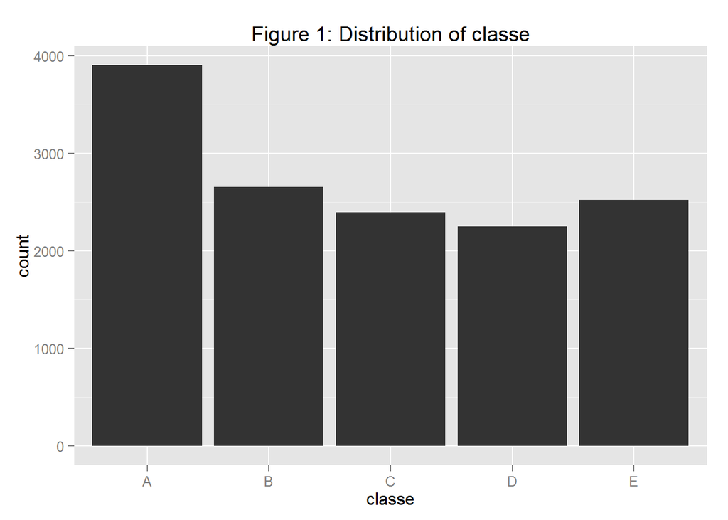

Despite a small tendency towards class A (correct execution), the outcome variable seems rather balanced: No value is extremely rare or extremely frequent.

### Variable importance

This step harnesses the C5.0 decision tree algorithm to estimate variable importance. In addition to ranking variables by their importance, it assists in focusing the matrix of predictors plots in the next step.

```r
# Set the number of folds for cross validation to 2
# (small K for quicker calculations, may not be enough for model fitting and error estimation)
fitControl_quick <- trainControl(
  method = "cv"
  ,number = 2
  ,repeats = 1
)

# Train a C5.0 tree
modelFit_c5_quick <- train(
  classe ~ .
  ,data=training
  ,method="C5.0"
  ,trControl = fitControl_quick
)

# Estimate variable importance
importance <- varImp(modelFit_c5_quick, scale=FALSE)
# Summarize importance
print(importance)
```

```
## C5.0 variable importance
##
##   only 20 most important variables shown (out of 31)
##
##                   Overall
## magnet_belt_y      100.00
## magnet_dumbbell_z  100.00
## yaw_belt           100.00
## gyros_belt_z       100.00
## pitch_forearm      100.00
## yaw_arm            100.00
## gyros_belt_y        99.96
## gyros_dumbbell_y    99.80
## magnet_belt_x       97.88
## magnet_arm_z        97.42
## magnet_forearm_z    97.31
## magnet_forearm_x    97.26
## roll_dumbbell       97.15
## gyros_belt_x        97.08
## gyros_arm_y         96.80
## roll_arm            96.27
## accel_forearm_z     95.62
## magnet_forearm_y    94.39
## pitch_arm           94.13
## gyros_forearm_x     89.90
```

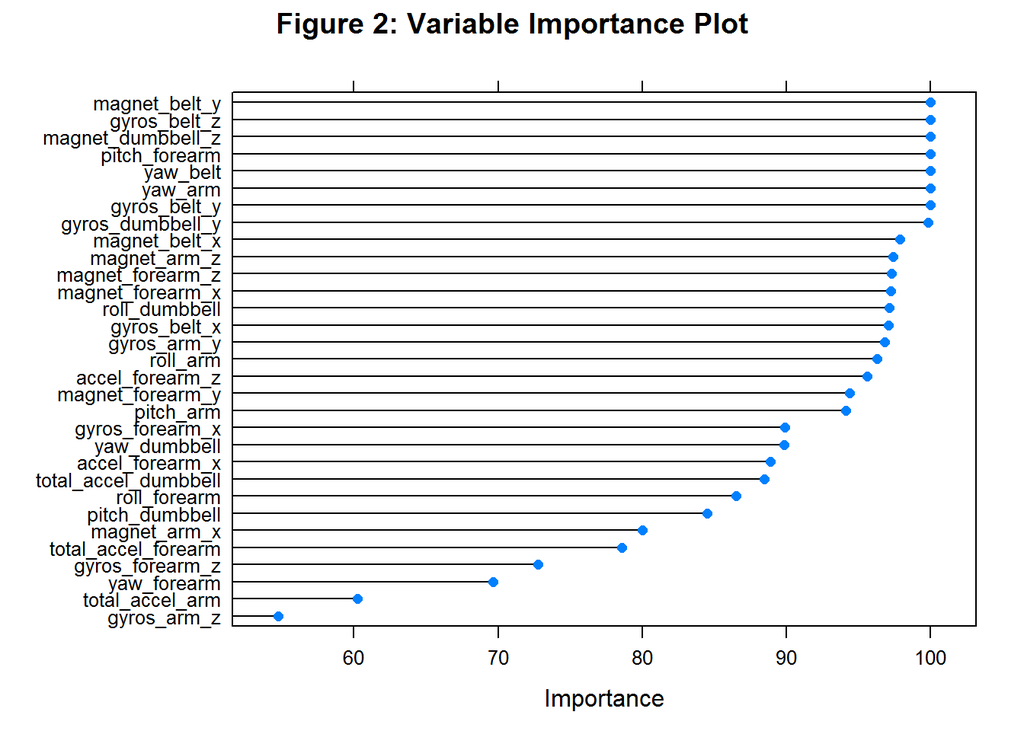

It seems that out of 31 predictors, 6 have a 100.00 importance: *pitch_forearm*, *yaw_arm* ,*magnet_dumbbell_z*, *magnet_belt_y*, *gyros_belt_z* and *yaw_belt*. The following predictors do not fall far behind, many of which with importance over 95.

### Matrix of predictors plots

In order not to produce an over-crowded plot, we will focus on 3 top variables by means of their importance calculated in the previous stage, namely *yaw_belt*, *gyros_belt_z* and *magnet_belt_y*.

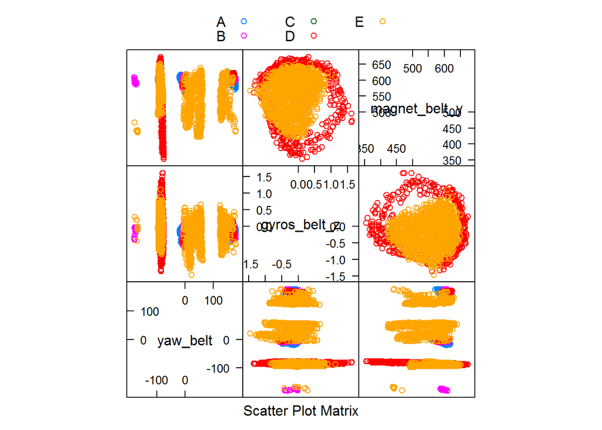

It is interesting to see that *magnet_belt_y* and *gyros_belt_z* distinguish well between classes *D* and *E*, with a spheric-like border. The predictor *yaw_belt* seems to assist in descriminating classes *A* and *B*. Class *C* may need additional predictors to be descriminated.

### A closer look into the combination of *yaw_belt* and *gyros_belt_z*

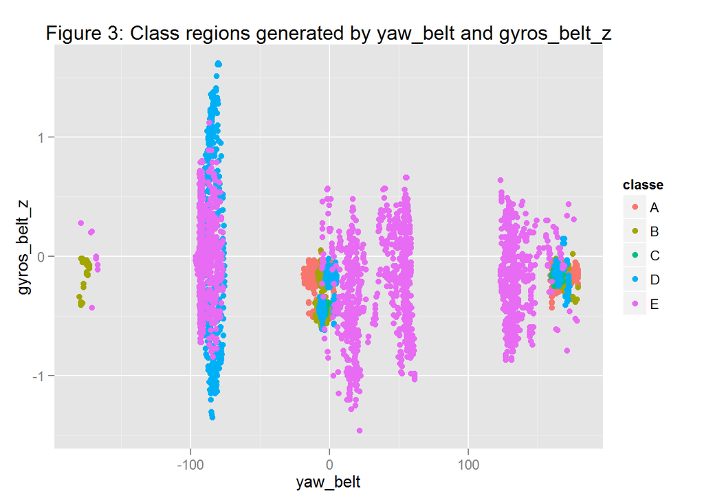

Some regions, such as approximately 20<*yaw_belt*<150, show excellrnt seperation of classes (class *E* in that case). Other regions, such as the upper end of *yaw_belt*, when *gyros_belt_z* is about 0, present mixed classes and may require further predictors for better classification.